# Skills Quiz: Simple Linear Regression

```r
# Load your libraries
library(car)
library(tidyverse)
library(mosaic)
library(pander)
library(ggplot2)
library(readr)
library(stringr)
library(DT)
```

## Instructions

Use this file to keep a record of your work as you complete the “Skills Quiz: Simple Linear Regression” assignment in I-Learn.

## Problem 1 {Done}

Open the `airquality` dataset in R. Perform a regression of daily average `Wind` speed using the daily maximum `Temp`erature as the explanatory variable.

### Part (a) {Done}

Type out the mathematical equation for this regression model and label both $Y$ and $X$ in the equation.

$$\underbrace{Y_i}_\text{Wind} = \beta_0 + \beta_1 \underbrace{X_i}_\text{Temp} + \epsilon_i \quad \text{where} \ \epsilon_i \sim N(0,\sigma^2)$$

### Part (b) {Done}

Fit and summarize a simple linear regression model for this data.

```r
# Type your code here

# Perform the Test
mylm <- lm(Wind ~ Temp, data = airquality)
pander(summary(mylm))
```

|  | Estimate | Std. Error | t value | Pr(>\|t\|) |
| --- | --- | --- | --- | --- |
| **(Intercept)** | 23.23 | 2.112 | 11 | 4.901e-21 |
| **Temp** | -0.1705 | 0.02693 | -6.331 | 2.642e-09 |

Fitting linear model: Wind ~ Temp

| Observations | Residual Std. Error | $R^2$ | Adjusted $R^2$ |
| --- | --- | --- | --- |
| 153 | 3.142 | 0.2098 | 0.2045 |

### Part (c) {Done}

Type out the estimated equation for this regression model using your estimates found in part (b).

$$\hat{Y}_i = \text{23.23} + \text{-0.1705} {X_i}$$

### Part (d) {Done}

Plot the data and the estimated regression model.

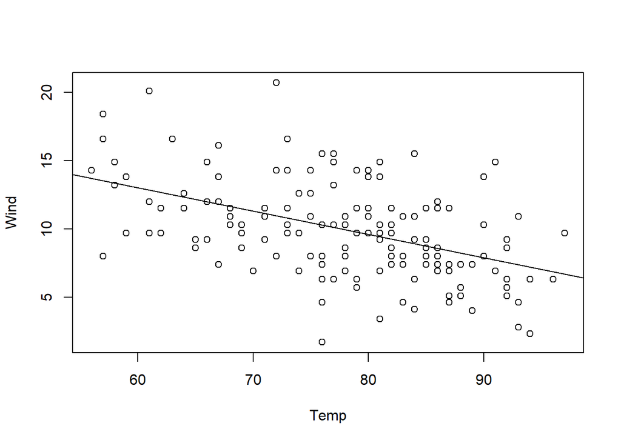

```r
#Plot the Regression Line
plot(Wind ~ Temp, data = airquality)
abline(mylm)
```

### Part (e) {Done}

Use your model to predict the average daily average Wind speed for an outside temperature of 72 degrees F.

```r
pander(23.23369 + -0.17046*72)
```

*10.96*

### Part (f) {Done}

Write out an interpretation of the slope and intercept of your model. Are both meaningful for this data?

## Problem 2 {Done}

Open the **mtcars** dataset in R. Fit a regression model to the data that can be used to explain average gas mileage of a vehicle (`mpg`) using the weight (`wt`) of the vehicle.

### Part (a) {Done}

Type out the mathematical equation for this regression model and label both $Y$ and $X$ in the equation.

$$\underbrace{Y_i}_\text{mpg} = \beta_0 + \beta_1 \underbrace{X_i}_\text{wt} + \epsilon_i \quad \text{where} \ \epsilon_i \sim N (0, \sigma^2)$$

### Part (b) {Done}

Fit and summarize a simple linear regression model for this data.

```r
# Type your code here

# Perform the Test
mylm2 <- lm(mpg ~ wt, data = mtcars)
summary(mylm2)
```

```
##
## Call:
## lm(formula = mpg ~ wt, data = mtcars)
##
## Residuals:
##     Min      1Q  Median      3Q     Max
## -4.5432 -2.3647 -0.1252  1.4096  6.8727
##
## Coefficients:
##             Estimate Std. Error t value Pr(>|t|)
## (Intercept)  37.2851     1.8776  19.858  < 2e-16 ***
## wt           -5.3445     0.5591  -9.559 1.29e-10 ***
## ---
## Signif. codes:  0 '***' 0.001 '**' 0.01 '*' 0.05 '.' 0.1 ' ' 1
##
## Residual standard error: 3.046 on 30 degrees of freedom
## Multiple R-squared:  0.7528, Adjusted R-squared:  0.7446
## F-statistic: 91.38 on 1 and 30 DF,  p-value: 1.294e-10
```

### Part (c) {Done}

Type out the estimated equation for this regression model using your estimates found in part (b).

$$\hat{Y}_i = 37.2851 + \text{-5.3445}X_i$$

### Part (d) {Done}

Plot the data and the estimated regression model.

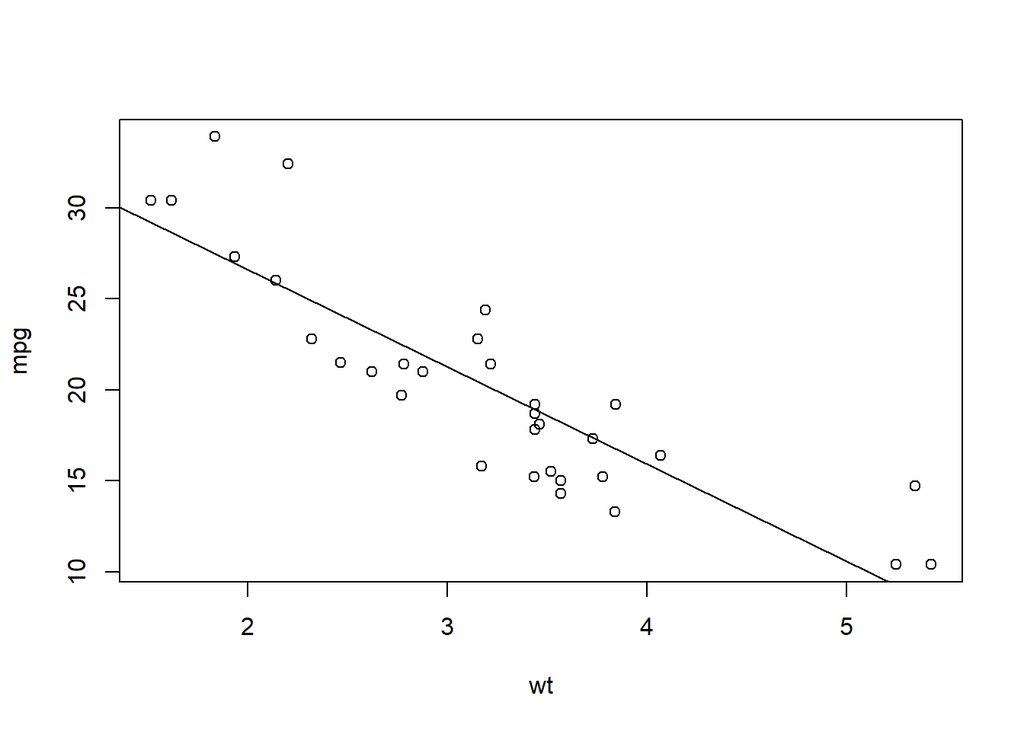

```r
# Type your code here

plot(mpg ~ wt, data = mtcars)
abline(mylm2)
```

### Part (e) {Done}

Use your model to predict the average gas mileage (mpg) for a vehicle that weighs 3,000 lbs. (Hint: ?mtcars)

```r
# Type your code here
#?mtcars
#View(mtcars)

pander(37.2851 + (-5.3445*3))
```

*21.25*

### Part (f) {Done}

Write out an interpretation of the slope and intercept of your model. Are both meaningful for this data?

For every one ton or 1,000 pounds a car weighs, the average miles per gallon drops by five miles (-5.3445) for these vehicles.

### Part (g) {Done}

Select the correct interpretation of the intercept of your model.

- The average gas mileage of vehicles that weigh nothing (0 lbs) is estimated to be 37.29 mpg.

Is the slope meaningful for this data?

- While the slope is significant, it only looks to be meaningful for vehicles that weigh between 2.5 thousand and 4 thousand pounds. Otherwise this regression does not seem to be a good fit for this data based on the scatterplot.

Is the intercept meaningful for this data?

- No, the intercept is not meaningful for this data because a vehicle with weight zero is not possible.

Before we can really trust the interpretation of and predictions from a regression model, there are important diagnostic checks to perform on the regression. These diagnostics are even more important to perform when p-values or confidence intervals are used as part of the analysis. In future weeks of this course, we will focus in greater detail on the technical details of regression: hypothesis tests, confidence intervals, and diagnostic checks. However, for the sake of completeness, the following problems have run through these technical details, even though we lack full understanding about them for the time being.

## Problem 3 {Done}

Use your regression for the `airquality` data set in **Problem 1** to complete the following “technical details” for this regression.

### Part (a) {Done}

Create a (1) residuals vs. fitted-values plot, (2) Q-Q Plot of the residuals, and (3) residuals vs. order plot.

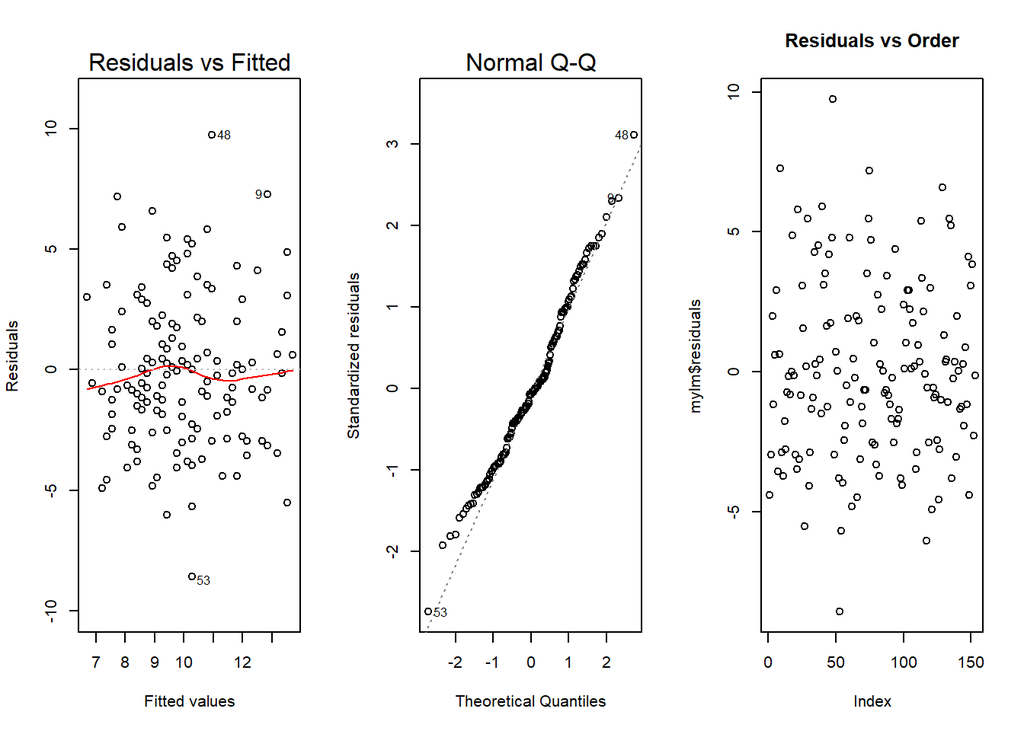

```r
# Check Assumptions
par(mfrow=c(1,3))
plot(mylm, which=1:2)
plot(mylm$residuals, main = "Residuals vs Order")
```

```r
#plot(mylm, which = 1)
#qqPlot(mylm$residuals, main = "Q-Q Plot of Residuals", id = FALSE)
```

### Part (b) {Done}

Explain, as best you understand currently, what each of these three plots show for this regression.

From the Residuals vs. Fitted plot, assumptions 1 and 3 are normal meaning that regression relationship is linear.  
From the Q-Q plot, assumption 2 is normal meaning that the error terms are normally distributed. The data slightly goes out of bounds, but looks normal enough.  
From the Residuals vs. Order plot, the error terms look like they are independent of one another making them normal.

### Part (c) {Done}

Report the p-value for the test of these hypotheses for your regression.

**Intercept Hypotheses**

$$H_0: \beta_0 = 0 \quad \text{vs.} \quad H_a: \beta_0 \neq 0$$

**Slope Hypotheses**

$$H_0: \beta_1 = 0 \quad \text{vs.} \quad H_a: \beta_1 \neq 0$$

Comment on whether or not we should trust each p-value based on your plots in Part (a).

Yes, the p-values may be trusted because the diagnostic plots check out.

## Problem 4 {Done}

Use your regression for the `mtcars` data set in **Problem 2** to complete the following “technical details” for this regression.

### Part (a) {Done}

Create a (1) residuals vs. fitted-values plot, (2) Q-Q Plot of the residuals, and (3) residuals vs. order plot.

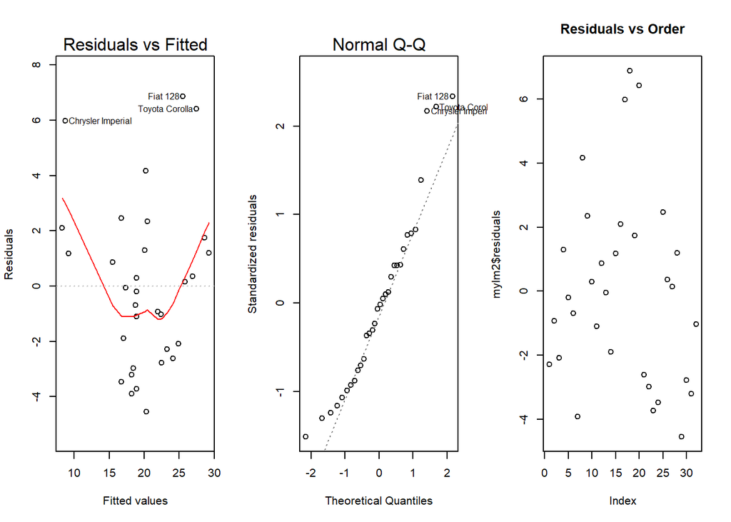

```r
# Check Assumptions
par(mfrow=c(1,3))
plot(mylm2, which=1:2)
plot(mylm2$residuals, main = "Residuals vs Order")
```

```r
#plot(mylm, which = 1)
#qqPlot(mylm2$residuals, main = "Q-Q Plot of Residuals", id = FALSE)
```

### Part (b) {Done}

Explain, as best you understand currently, what each of these three plots show for this regression.

Everything looks normal except for the Residuals vs. Fitted plot. There is a noticeable trend with the error terms not being linear.

**Update** - The Residuals vs Order plot have a rainbow trend going. The error terms may not then be independent of one another.

### Part (c) {Done}

Report the p-value for the test of these hypotheses for your regression.

**Intercept Hypotheses**

$$H_0: \beta_0 = 0 \quad \text{vs.} \quad H_a: \beta_0 \neq 0$$

**Slope Hypotheses**

$$H_0: \beta_1 = 0 \quad \text{vs.} \quad H_a: \beta_1 \neq 0$$

Comment on whether or not we should trust each p-value based on your plots in Part (a).

The p-values should not be trusted because the assumptions diagnotics did not show the data as being normal.